# AutoBench demo

### Import Libraries

```python
# Ours
import auto_bench.main
import auto_bench.metrics
import auto_bench.transforms
import auto_bench.utils

# Public
import numpy as np
import seaborn as sns
import matplotlib.pyplot as plt
import csv
import pickle
sns.set_style("darkgrid")
```

### Define out subjects / trials, and where this data lives.

```python
subjects = ['A00054207', 'A00054387']
trials = [range(1, 6),
          range(1, 6)]
base_path = '../data/thicc_folder/'
```

Data should be stored in the `base_path` with file names beginning with the subjects and ending with a 3-digit trial number. E.g., subject `A00054207` trial 1 should be in `A00054207001.ext` where `.ext` is `.csv` ( or `.pkl` if you have used the conversion script below. )

### How to convert from .csv to .pkl (for optimized memory and loading)

```python
auto_bench.utils.csv_to_pkl(subjects, trials, base_path)
```

```
Loading ../data/thicc_folder/A00054207001.csv
Saving ../data/thicc_folder/A00054207001.pkl
Loading ../data/thicc_folder/A00054207002.csv
Saving ../data/thicc_folder/A00054207002.pkl
Loading ../data/thicc_folder/A00054207003.csv
Saving ../data/thicc_folder/A00054207003.pkl
Loading ../data/thicc_folder/A00054207004.csv
Saving ../data/thicc_folder/A00054207004.pkl
Loading ../data/thicc_folder/A00054207005.csv
Saving ../data/thicc_folder/A00054207005.pkl
Loading ../data/thicc_folder/A00054387001.csv
Saving ../data/thicc_folder/A00054387001.pkl
Loading ../data/thicc_folder/A00054387002.csv
Saving ../data/thicc_folder/A00054387002.pkl
Loading ../data/thicc_folder/A00054387003.csv
Saving ../data/thicc_folder/A00054387003.pkl
Loading ../data/thicc_folder/A00054387004.csv
Saving ../data/thicc_folder/A00054387004.pkl
Loading ../data/thicc_folder/A00054387005.csv
Saving ../data/thicc_folder/A00054387005.pkl
```

### Why did we do that? (Its faster to load in)

```python
path = '../data/thicc_folder/'
subj_name = '%s%03d' % (subjects[0], trials[0][2])
csv_path = path + subj_name + '.csv'
pkl_path = path + subj_name + '.pkl'
print 'Time taken to load .csv:'
%timeit auto_bench.utils.fast_csv_load(csv_path)
print
print 'Time taken to load .pkl'
%timeit with open(pkl_path, 'rb') as f: pickle.load(f)
print
```

```
Time taken to load .csv:
1 loop, best of 3: 1.63 s per loop

Time taken to load .pkl
The slowest run took 65.59 times longer than the fastest. This could mean that an intermediate result is being cached.
1 loop, best of 3: 9.93 ms per loop
```

Also, the size of a .pkl is about 1/2 the size of a .csv for this data.

### Load In the Data

Only loads in .pkl files for now. Use the conversion script above.

```python
D, L = auto_bench.utils.load_data(subjects,
                                  trials,
                                  base_path)
```

```
Loading A00054207001
Loading A00054207002
Loading A00054207003
Loading A00054207004
Loading A00054207005
Loading A00054387001
Loading A00054387002
Loading A00054387003
Loading A00054387004
Loading A00054387005
```

### Information about the data set

```python
auto_bench.utils.print_info(D, L)
```

```
         Label          Shape       Type
     A00054207  (128, 187999)    float32
     A00054207  (128, 125029)    float32
     A00054207   (128, 81177)    float32
     A00054207  (128, 131928)    float32
     A00054207  (128, 108527)    float32
     A00054387  (128, 171655)    float32
     A00054387  (128, 138053)    float32
     A00054387   (128, 89177)    float32
     A00054387  (128, 136728)    float32
     A00054387  (128, 105827)    float32
```

### Define the pre-processing method in a function which takes in trials and dictionaries of parameters and returns modified data trials.

E.g., in this sample, we define a function which takes in a EEG scan and returns the EEG scan with some PCA based denoising. We will also define a robust variant, which splits the data into a sum of a low rank and sparse matrix, and will continue with the sparse component thrown out.

```python
from pcp import pcp
def pca_denoise(d, params):
    k = params['k'] # Number of singular vectors to take.
    s = params['s'] # Number of random data points to compute on.
    samp = np.random.choice(d.shape[1], s, replace=False)
    d_samp = d[:, samp]
    m = np.mean(d_samp, axis=1).reshape(-1, 1)
    d_cent = d_samp - m
    U, _, _ = np.linalg.svd(d_cent, full_matrices = False)
    P_k = U[:, :k].dot(U[:, :k].T)
    proj = P_k.dot(d)
    return proj

def robust_pca_denoise(d, params):
    k = params['k'] # Number of singular vectors to take.
    s = params['s'] # Number of random data points to compute on.
    samp = np.random.choice(d.shape[1], s, replace=False)
    d_samp = d[:, samp]
    d_samp, _ , _ = pcp(d_samp,
                        maxiter=50,
                        verbose=False,
                        svd_method="approximate")
    m = np.mean(d_samp, axis=1).reshape(-1, 1)
    d_cent = d_samp - m
    U, _, _ = np.linalg.svd(d_cent, full_matrices = False)
    P_k = U[:, :k].dot(U[:, :k].T)
    proj = P_k.dot(d)
    return proj
```

### Look at the behavior of transformation - metric pairs on the discriminibility of raw data. See which one you want to test (or which subset).

```
Corr F
Norm Corr Spec
D # C(3) .7
D # C(3) .5
D # C(4) .7
D # C(4) .5
```

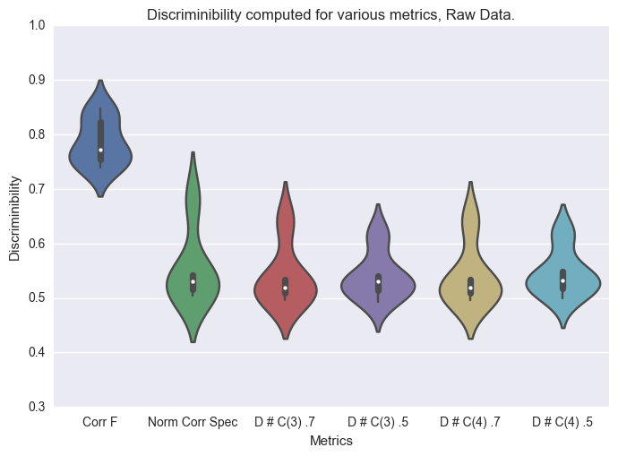

```python
transforms = [auto_bench.transforms.correl,
              auto_bench.transforms.correl_spec,
              auto_bench.transforms.tc_make(.7),
              auto_bench.transforms.tc_make(.5),
              auto_bench.transforms.tc_make(.7),
              auto_bench.transforms.tc_make(.5)]

metrics = [auto_bench.metrics.frob,
           auto_bench.metrics.frob,
           auto_bench.metrics.diff_num_3cycle,
           auto_bench.metrics.diff_num_3cycle,
           auto_bench.metrics.diff_num_4cycle,
           auto_bench.metrics.diff_num_4cycle]

names = ['Corr F',
         'Norm Corr Spec',
         'D # C(3) .7',
         'D # C(3) .5',
         'D # C(4) .7',
         'D # C(4) .5']

title = 'Discriminibility computed for various metrics, Raw Data.'
results_raw = auto_bench.main.metric_benchmark(D,
                                               L,
                                               transforms,
                                               metrics,
                                               names,
                                               title)
```

### Define a transformation to the object on which discriminibility is calculated.

For example, we can calculate a metric on the correlation matrix, the coherence matrix, the raw data matrix, the left singular vectors, ect.

Define what should happen to each data matrix to get into this format.

```python
transform = auto_bench.transforms.correl
```

### Define the metric on the objects returned from the above transformation.

E.g., if the object is a correlation matrix, it should expect a $\mathbb{R}^{D \times D}$ matrix, where $D$ is the number of channels. Should take in two data objects and compute the frob norm.

```python
metric = auto_bench.metrics.frob
```

### Benchmark the data using the above framework.

```
Got a parameter space of dimension [3, 2]
Found partially completed run for the name pca_denoise ... loading that.
Already found param combination {'k': 2, 's': 5000}
Already found param combination {'k': 2, 's': 20000}
Already found param combination {'k': 5, 's': 5000}
Already found param combination {'k': 5, 's': 20000}
Already found param combination {'k': 10, 's': 5000}
Already found param combination {'k': 10, 's': 20000}
```

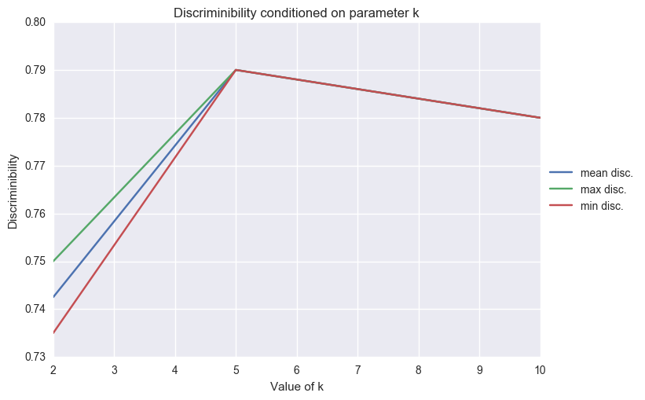

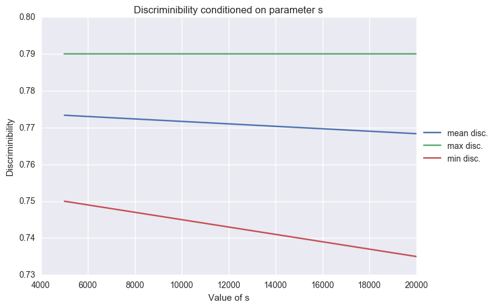

```python
# Set possible values of the parameters.
param_map = {
    'k': [2, 5, 10],
    's': [5000, 20000]
}

# Normal PCA
R = auto_bench.main.bench(
    D, # data array
    L, # subject id, corresponding to D
    param_map, # all parameters to run over
    metric, # metric
    transform, # transformation
    pca_denoise, # the preprocessing routine
    name = 'pca_denoise'
) # name of this test

auto_bench.main.bench_report(
        R, # result from bench function
        param_map, # param_map used in bench
        'PCA Denoise', # name of pre processing
        'Frob. Norm of Correlation Matricies' # comparison
    )
```

```python
R = auto_bench.main.bench(
    D, # data array
    L, # subject id, corresponding to D
    param_map, # all parameters to run over
    metric, # metric
    transform, # transformation
    robust_pca_denoise, # the preprocessing routine
    name = 'robust_pca_denoise'
) # name of this test

auto_bench.main.bench_report(
        R, # result from bench function
        param_map, # param_map used in bench
        'Robust PCA Denoise', # name of pre processing
        'Frob. Norm of Correlation Matricies' # comparison
    )
```

[output not shown]

```
Got a parameter space of dimension [3, 2]
Found partially completed run for the name robust_pca_denoise ... loading that.
Already found param combination {'k': 2, 's': 5000}
```

### Find the optimal parameter setting

```python
best_params, best_idx = auto_bench.main.best_param_combo(R, param_map)
print 'Best parameter setting:', best_params
print 'Discriminibility from this setting:', R[best_idx]
```

```
Best parameter setting: {'k': 5, 's': 5000}
Discriminibility from this setting: 0.79
```

```python
raw_results = auto_bench.main.single_bench(
    D, # Data
    L, # Labels
    None, # Best parameter setting (None if no preprocess.)
    metric, # Metric for disc.
    transform, # Transform to new representation for disc.
    None # Preprocessing routine
)
```

```python
preprocessed_results = auto_bench.main.single_bench(
    D,
    L,
    best_params,
    metric,
    transform,
    pca_denoise
)
```

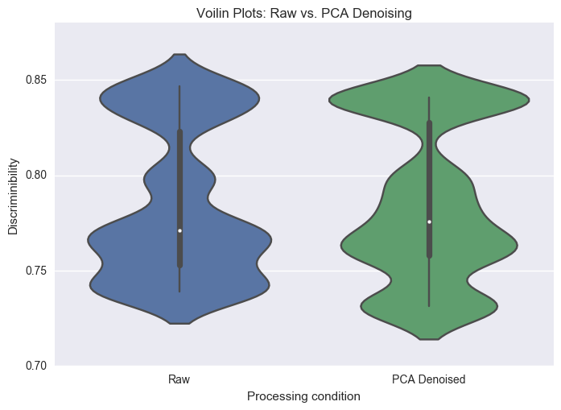

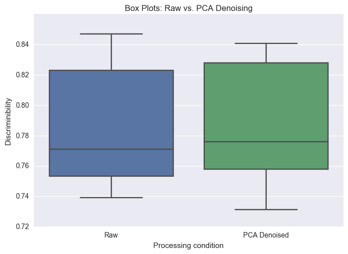

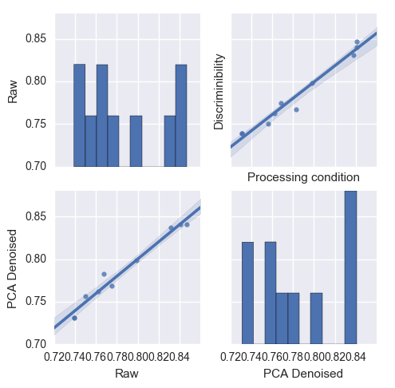

```python
results = [(raw_results, 'Raw'),
           (preprocessed_results, 'PCA Denoised')]
title = "Raw vs. PCA Denoising"
auto_bench.main.compare_results(results, title)
```